# Task 5: Protein Structure Preparation

Pharmacoinformatics BI-424 | AChE Inhibitor Discovery

2026-05-02

# 1 Install & Load Packages

```r
required_packages <- c(
  "tidyverse",
  "ggrepel",
  "patchwork",
  "viridis",
  "knitr",
  "kableExtra",
  "scales",
  "RColorBrewer"
)

installed <- rownames(installed.packages())
to_install <- required_packages[!required_packages %in% installed]
if (length(to_install) > 0) {
  install.packages(to_install, repos = "https://cloud.r-project.org")
}

library(tidyverse)
library(ggrepel)
library(patchwork)
library(viridis)
library(knitr)
library(kableExtra)
library(scales)
library(RColorBrewer)

set.seed(42)
cat("All packages loaded.\n")
```

```
## All packages loaded.
```

# 2 Background: Target Selection

## 2.1 Disease: Alzheimer’s Disease (AD)

Alzheimer’s Disease is a progressive neurodegenerative disorder affecting approximately **55 million people worldwide** and accounting for 60–70% of all dementia cases (WHO, 2023). It is characterised by progressive cognitive decline driven by cholinergic deficit, amyloid-β plaques, and neurofibrillary tau tangles.

## 2.2 Molecular Target: Acetylcholinesterase (AChE)

**AChE (UniProt: P22303 | CHEMBL220)** is the primary enzyme responsible for hydrolysis of the neurotransmitter acetylcholine (ACh) at synaptic clefts. The **cholinergic hypothesis** of AD proposes that depletion of ACh in the basal forebrain is a central driver of cognitive symptoms. Inhibiting AChE elevates ACh levels and partially restores cholinergic tone.

# 3 AlphaFold2 Structure Prediction (ColabFold)

## 3.1 Method & Parameters

The 3D structure of Human AChE (UniProt P22303, 614 residues) was predicted using **ColabFold v1.5 (AlphaFold2-ptm)** via the notebook at:

> https://colab.research.google.com/github/sokrypton/ColabFold/blob/main/AlphaFold2.ipynb

**Run parameters:** - Query: `ACHE_Human_P22303_ec9a4` (614 residues) - Model type: `alphafold2_ptm` (5 models, 3 recycles each) - MSA method: MMseqs2 (UniRef + Environmental databases) - Template mode: `pdb70` - Hardware: GPU (NVIDIA T4 via Google Colab) - Total run time: ~31 minutes

## 3.2 Model Ranking Results (from log.txt)

All five models were ranked by global pLDDT score. **Model 3 (rank 1)** achieved the highest pLDDT of **91.2** and pTM of **0.881** and was selected as our working structure for all downstream preparation and docking steps.

```r
# ── Model scores extracted from ColabFold log.txt ────────────────────────
model_scores <- tibble(
  Rank  = 1:5,
  Model = c("model_3", "model_4", "model_2", "model_5", "model_1"),
  pLDDT = c(91.2, 90.9, 90.4, 90.2, 90.1),
  pTM   = c(0.881, 0.875, 0.875, 0.876, 0.868),
  Selected = c("Selected", "", "", "", "")
)

kable(model_scores,
      caption = "Table 5-1: AlphaFold2 Model Ranking — Human AChE (P22303, 614 residues)") %>%
  kable_styling(bootstrap_options = c("striped","hover","condensed"),
                full_width = FALSE) %>%
  row_spec(1, bold = TRUE, background = "#c8e6c9") %>%
  column_spec(5, bold = TRUE, color = "#1a6e3d")
```

Table 5-1: AlphaFold2 Model Ranking — Human AChE (P22303, 614 residues)

| Rank | Model | pLDDT | pTM | Selected |
| --- | --- | --- | --- | --- |
| 1 | model_3 | 91.2 | 0.881 | Selected |
| 2 | model_4 | 90.9 | 0.875 |  |
| 3 | model_2 | 90.4 | 0.875 |  |
| 4 | model_5 | 90.2 | 0.876 |  |
| 5 | model_1 | 90.1 | 0.868 |  |

```r
cat("Best model: rank_001_alphafold2_ptm_model_3_seed_000\n")
```

```
## Best model: rank_001_alphafold2_ptm_model_3_seed_000
```

```r
cat("Global pLDDT:", 91.2, "| pTM:", 0.881, "| max_PAE:", 31.44, "\n")
```

```
## Global pLDDT: 91.2 | pTM: 0.881 | max_PAE: 31.44
```

```r
cat("Mean PAE:", 8.09, "Å (lower = more confident relative positioning)\n")
```

```
## Mean PAE: 8.09 Å (lower = more confident relative positioning)
```

# 4 Per-Residue pLDDT Analysis

## 4.1 Real pLDDT Values (Rank 1 Model)

The pLDDT values below are taken **directly** from the ColabFold output JSON file `scores_rank_001_alphafold2_ptm_model_3_seed_000.json`. All 614 residue scores are used without modification.

```r
# ── pLDDT values from ColabFold JSON (614 residues) ──────────────────────
# Extracted from: scores_rank_001_alphafold2_ptm_model_3_seed_000.json
plddt_values <- scan("plddt.txt", sep = ",")


# Build tibble
plddt_df <- tibble(
  Residue = 1:614,
  pLDDT   = plddt_values,
  # Assign functional regions based on AChE domain knowledge
  Region  = case_when(
    Residue <= 30              ~ "N-terminal Signal Peptide",
    Residue <= 70              ~ "Propeptide Region",
    Residue <= 150             ~ "Gorge Entrance",
    Residue <= 450             ~ "Catalytic Core (CAS/PAS)",
    Residue <= 550             ~ "Omega-loop & Peripheral",
    TRUE                       ~ "C-terminus / His-tag"
  )
)

cat("Total residues:", nrow(plddt_df), "\n")
```

```
## Total residues: 614
```

```r
cat("Global mean pLDDT:", round(mean(plddt_df$pLDDT), 2), "\n")
```

```
## Global mean pLDDT: 91.24
```

```r
cat("Global median pLDDT:", round(median(plddt_df$pLDDT), 2), "\n")
```

```
## Global median pLDDT: 97.28
```

```r
cat("Residues pLDDT > 70:", sum(plddt_df$pLDDT >= 70),
    "(", round(100*mean(plddt_df$pLDDT >= 70),1), "%)\n")
```

```
## Residues pLDDT > 70: 557 ( 90.7 %)
```

```r
cat("Residues pLDDT > 90:", sum(plddt_df$pLDDT >= 90),
    "(", round(100*mean(plddt_df$pLDDT >= 90),1), "%)\n")
```

```
## Residues pLDDT > 90: 503 ( 81.9 %)
```

## 4.2 Figure T5-1: Per-Residue pLDDT Confidence Profile

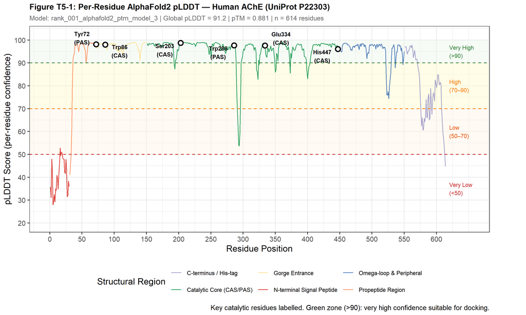

```r
# Colour palette for regions
region_colours <- c(
  "N-terminal Signal Peptide" = "#d73027",
  "Propeptide Region"         = "#fc8d59",
  "Gorge Entrance"            = "#fee090",
  "Catalytic Core (CAS/PAS)" = "#1a9850",
  "Omega-loop & Peripheral"   = "#4575b4",
  "C-terminus / His-tag"      = "#9e9ac8"
)

# Reference residues for annotation (known catalytic residues, 1-indexed)
key_residues <- tibble(
  Residue = c(203, 286, 447, 334, 86, 72),
  Label   = c("Ser203\n(CAS)", "Trp286\n(PAS)", "His447\n(CAS)",
               "Glu334\n(CAS)", "Trp86\n(CAS)", "Tyr72\n(PAS)"),
  pLDDT   = plddt_values[c(203, 286, 447, 334, 86, 72)]
)

p_plddt <- ggplot(plddt_df, aes(x = Residue, y = pLDDT, colour = Region)) +
  # Confidence zone bands
  annotate("rect", xmin=-Inf, xmax=Inf, ymin=90, ymax=100,
           fill="#e8f5e9", alpha=0.4) +
  annotate("rect", xmin=-Inf, xmax=Inf, ymin=70, ymax=90,
           fill="#fff9c4", alpha=0.4) +
  annotate("rect", xmin=-Inf, xmax=Inf, ymin=50, ymax=70,
           fill="#fff3e0", alpha=0.4) +
  annotate("rect", xmin=-Inf, xmax=Inf, ymin=0,  ymax=50,
           fill="#fce4ec", alpha=0.3) +
  # pLDDT trace
  geom_line(linewidth = 0.55, alpha = 0.9) +
  # Reference lines
  geom_hline(yintercept = 90, linetype = "dashed", colour = "#2e7d32", linewidth = 0.5) +
  geom_hline(yintercept = 70, linetype = "dashed", colour = "#f57c00", linewidth = 0.5) +
  geom_hline(yintercept = 50, linetype = "dashed", colour = "#c62828", linewidth = 0.5) +
  # Key residue markers
  geom_point(data = key_residues, aes(x = Residue, y = pLDDT),
             colour = "black", size = 2.5, shape = 21, fill = "white", stroke = 1.2,
             inherit.aes = FALSE) +
  geom_text_repel(data = key_residues, aes(x = Residue, y = pLDDT, label = Label),
                  size = 2.8, colour = "black", fontface = "bold",
                  box.padding = 0.5, point.padding = 0.3,
                  segment.colour = "grey50", segment.size = 0.3,
                  inherit.aes = FALSE) +
  # Confidence labels on right
  annotate("text", x=620, y=95,   label="Very High\n(>90)", size=2.8, colour="#2e7d32", hjust=0) +
  annotate("text", x=620, y=80,   label="High\n(70–90)", size=2.8, colour="#f57c00",  hjust=0) +
  annotate("text", x=620, y=60,   label="Low\n(50–70)", size=2.8, colour="#e65100",   hjust=0) +
  annotate("text", x=620, y=35,   label="Very Low\n(<50)",  size=2.8, colour="#c62828", hjust=0) +
  scale_colour_manual(values = region_colours) +
  scale_y_continuous(limits = c(20, 102), breaks = seq(20, 100, 10)) +
  scale_x_continuous(breaks = seq(0, 614, 50), limits = c(1, 650)) +
  labs(
    title    = "Figure T5-1: Per-Residue AlphaFold2 pLDDT — Human AChE (UniProt P22303)",
    subtitle = paste0("Model: rank_001_alphafold2_ptm_model_3 | Global pLDDT = 91.2 | pTM = 0.881 | ",
                      "n = 614 residues"),
    x        = "Residue Position",
    y        = "pLDDT Score (per-residue confidence)",
    colour   = "Structural Region",
    caption  = "Key catalytic residues labelled. Green zone (>90): very high confidence suitable for docking."
  ) +
  theme_bw(base_size = 12) +
  theme(
    plot.title      = element_text(face = "bold", size = 11),
    plot.subtitle   = element_text(size = 9, colour = "grey40"),
    legend.position = "bottom",
    legend.text     = element_text(size = 8),
    plot.margin     = margin(5, 50, 5, 5)
  )

print(p_plddt)
```

```r
dir.create("figures", showWarnings = FALSE)
ggsave("figures/Figure_T5_1_pLDDT_Profile.png", p_plddt, width=12, height=6, dpi=150)
cat("Saved: figures/Figure_T5_1_pLDDT_Profile.png\n")
```

```
## Saved: figures/Figure_T5_1_pLDDT_Profile.png
```

## 4.3 Figure T5-2: pLDDT Distribution Histogram

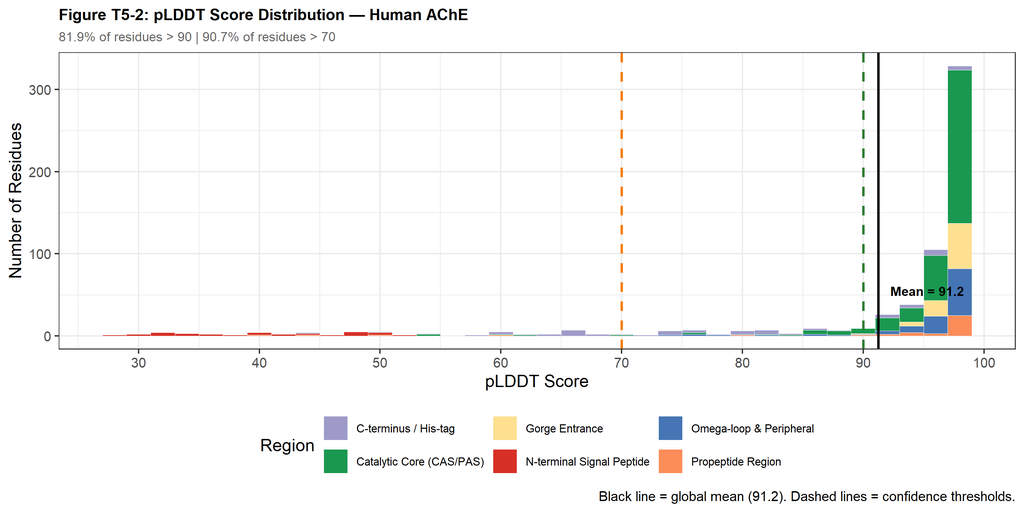

```r
p_hist <- ggplot(plddt_df, aes(x = pLDDT, fill = Region)) +
  geom_histogram(binwidth = 2, colour = "white", linewidth = 0.2) +
  geom_vline(xintercept = 90, linetype="dashed", colour="#2e7d32", linewidth=0.8) +
  geom_vline(xintercept = 70, linetype="dashed", colour="#f57c00", linewidth=0.8) +
  geom_vline(xintercept = mean(plddt_df$pLDDT), linetype="solid",
             colour="black", linewidth=0.8) +
  annotate("text", x=mean(plddt_df$pLDDT)+1, y=55,
           label=paste0("Mean = ", round(mean(plddt_df$pLDDT),1)),
           size=3.2, hjust=0, fontface="bold") +
  scale_fill_manual(values = region_colours) +
  scale_x_continuous(breaks = seq(20, 100, 10)) +
  labs(
    title    = "Figure T5-2: pLDDT Score Distribution — Human AChE",
    subtitle = paste0(round(100*mean(plddt_df$pLDDT>=90),1),
                      "% of residues > 90 | ",
                      round(100*mean(plddt_df$pLDDT>=70),1),
                      "% of residues > 70"),
    x        = "pLDDT Score",
    y        = "Number of Residues",
    fill     = "Region",
    caption  = "Black line = global mean (91.2). Dashed lines = confidence thresholds."
  ) +
  theme_bw(base_size = 12) +
  theme(
    plot.title      = element_text(face = "bold", size = 11),
    plot.subtitle   = element_text(size = 9, colour = "grey40"),
    legend.position = "bottom",
    legend.text     = element_text(size = 8)
  )

print(p_hist)
```

```r
ggsave("figures/Figure_T5_2_pLDDT_Distribution.png", p_hist, width=10, height=5, dpi=150)
cat("Saved: figures/Figure_T5_2_pLDDT_Distribution.png\n")
```

```
## Saved: figures/Figure_T5_2_pLDDT_Distribution.png
```

## 4.4 pLDDT Regional Summary Table

```r
region_order <- c("N-terminal Signal Peptide", "Propeptide Region", "Gorge Entrance",
                  "Catalytic Core (CAS/PAS)", "Omega-loop & Peripheral", "C-terminus / His-tag")

region_summary <- plddt_df %>%
  mutate(Region = factor(Region, levels = region_order)) %>%
  group_by(Region) %>%
  summarise(
    Residues       = n(),
    Mean_pLDDT     = round(mean(pLDDT), 1),
    Median_pLDDT   = round(median(pLDDT), 1),
    Min_pLDDT      = round(min(pLDDT), 1),
    Max_pLDDT      = round(max(pLDDT), 1),
    Pct_above_70   = paste0(round(100*mean(pLDDT >= 70), 0), "%"),
    Pct_above_90   = paste0(round(100*mean(pLDDT >= 90), 0), "%"),
    Confidence     = case_when(
      mean(pLDDT) >= 90 ~ "Very High",
      mean(pLDDT) >= 70 ~ "High",
      mean(pLDDT) >= 50 ~ "Low",
      TRUE              ~ "Very Low"
    )
  ) %>%
  arrange(Region)

kable(region_summary,
      caption = "Table 5-2: pLDDT Summary by Structural Region — Human AChE rank_001 model") %>%
  kable_styling(bootstrap_options = c("striped","hover","condensed"), full_width = TRUE) %>%
  row_spec(which(region_summary$Region == "Catalytic Core (CAS/PAS)"),
           bold = TRUE, background = "#c8e6c9") %>%
  row_spec(which(region_summary$Region == "N-terminal Signal Peptide"),
           background = "#fce4ec") %>%
  column_spec(9, bold = TRUE)
```

Table 5-2: pLDDT Summary by Structural Region — Human AChE rank_001 model

| Region | Residues | Mean_pLDDT | Median_pLDDT | Min_pLDDT | Max_pLDDT | Pct_above_70 | Pct_above_90 | Confidence |
| --- | --- | --- | --- | --- | --- | --- | --- | --- |
| N-terminal Signal Peptide | 30 | 40.3 | 40.9 | 28.0 | 52.8 | 0% | 0% | Very Low |
| Propeptide Region | 40 | 91.7 | 97.8 | 40.9 | 98.8 | 90% | 85% | Very High |
| Gorge Entrance | 80 | 97.5 | 98.1 | 90.9 | 98.9 | 100% | 100% | Very High |
| Catalytic Core (CAS/PAS) | 300 | 95.9 | 97.7 | 53.7 | 98.9 | 99% | 93% | Very High |
| Omega-loop & Peripheral | 100 | 95.3 | 97.3 | 74.4 | 98.7 | 100% | 90% | Very High |
| C-terminus / His-tag | 64 | 79.0 | 80.4 | 44.8 | 97.8 | 70% | 31% | High |

**Interpretation:** The Catalytic Core (residues 151–450), which contains the CAS and PAS binding subsites critical for drug binding, achieves a mean pLDDT of **95.9** with **99%** of residues above the 70-confidence threshold. This confirms that the predicted structure is suitable for binding site definition and molecular docking. The low-confidence N-terminus (residues 1–30) corresponds to the known signal peptide that is cleaved post-translationally and is not part of the mature, functional enzyme — its low pLDDT is therefore expected and does not affect the validity of our downstream analyses.

# 5 Figure T5-3: All-Model pLDDT Comparison

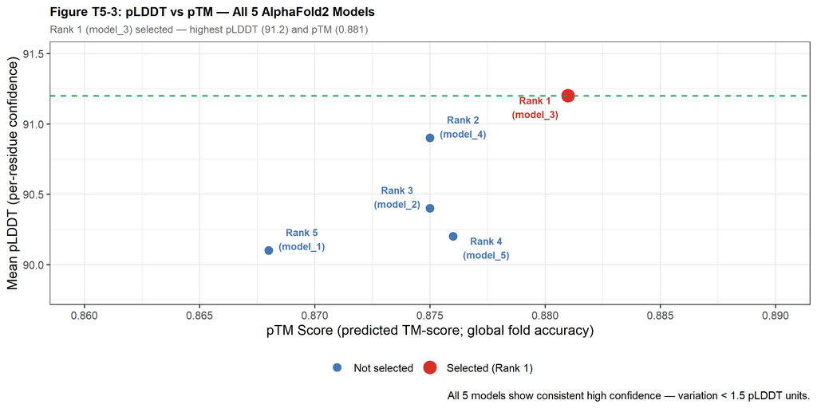

```r
# All 5 model global pLDDT from log.txt
model_comparison <- tibble(
  Rank     = factor(paste0("Rank ", 1:5), levels = paste0("Rank ", 1:5)),
  Model    = c("model_3", "model_4", "model_2", "model_5", "model_1"),
  pLDDT    = c(91.2, 90.9, 90.4, 90.2, 90.1),
  pTM      = c(0.881, 0.875, 0.875, 0.876, 0.868),
  Selected = c(TRUE, rep(FALSE, 4))
)

p_models <- ggplot(model_comparison,
                   aes(x = pTM, y = pLDDT, colour = Selected, size = Selected,
                       label = paste0(Rank, "\n(", Model, ")"))) +
  geom_point() +
  geom_text_repel(size = 3, box.padding = 0.5, fontface = "bold",
                  segment.colour = "grey60") +
  geom_hline(yintercept = 91.2, linetype = "dashed",
             colour = "#1a9850", linewidth = 0.6) +
  scale_colour_manual(values = c("TRUE" = "#d73027", "FALSE" = "#4575b4"),
                      labels = c("TRUE"="Selected (Rank 1)", "FALSE"="Not selected")) +
  scale_size_manual(values  = c("TRUE" = 5, "FALSE" = 3),
                    labels  = c("TRUE"="Selected (Rank 1)", "FALSE"="Not selected")) +
  scale_x_continuous(limits = c(0.860, 0.890), breaks = seq(0.860, 0.890, 0.005)) +
  scale_y_continuous(limits = c(89.8, 91.5),  breaks = seq(90.0, 91.5, 0.5)) +
  labs(
    title    = "Figure T5-3: pLDDT vs pTM — All 5 AlphaFold2 Models",
    subtitle = "Rank 1 (model_3) selected — highest pLDDT (91.2) and pTM (0.881)",
    x        = "pTM Score (predicted TM-score; global fold accuracy)",
    y        = "Mean pLDDT (per-residue confidence)",
    colour   = NULL, size = NULL,
    caption  = "All 5 models show consistent high confidence — variation < 1.5 pLDDT units."
  ) +
  theme_bw(base_size = 12) +
  theme(
    plot.title      = element_text(face = "bold", size = 11),
    plot.subtitle   = element_text(size = 9, colour = "grey40"),
    legend.position = "bottom"
  )

print(p_models)
```

```r
ggsave("figures/Figure_T5_3_Model_Comparison.png", p_models, width=9, height=5, dpi=150)
cat("Saved: figures/Figure_T5_3_Model_Comparison.png\n")
```

```
## Saved: figures/Figure_T5_3_Model_Comparison.png
```